# CS 372/472 & LRN_SCI 372/472

Extending Models (pt 2)

Prof. Connor Bain

connor.bain@northwestern.edu

April 21, 2026

## Logistical Stuff

**Exercise 4**

- Is due on SUNDAY at 11:59pm via Canvas.
- It’s asking you to start thinking about your final project so it’s less “work” and more “thinking.”
- Budget some time this week for a nice walk around the lakefill to start brainstorming.
- I’ll have office hours from 3pm to 5pm on Wednesday in TCH L374 if you’d like to come by and chat about ideas.
  - 3pm to 3:30pm on Zoom - email me for the link
  - 3:30pm to 5pm in person (TCH L374)

## Recap - Self-organized Criticality

- In 1987, Danish physicist and complex systems theorist Per Bak and his colleagues showed that the many real world phenomenon display a *critical parameter*. (Bak 1996)
- Forest fires have been of particular interest to mathematicians and have been shown to display *self-organized criticality*. (Malamud et al. 1998)
- Informally, some of these models are referred to as tipping point models.
- Why do we care?
  - If you know there’s a tipping point somewhere, putting more effort into the system while *seemingly* useless could reap results.
  - Or correlatively, if you know how close you are to the tipping point, you can better judge how “worth it” more effort would be.

## Recap - Extending Models

- Change hard-coded values to parameters, such as with a slider or chooser or switch
- Make a global variable heterogeneous across turtles or patches
- Turn deterministic behavior to probabilistic
- Expand the types of behaviors agents can have
- **Focus on particular mechanisms that might have been pushed into a probability**
- Add more measures and displays for communication and analysis

## Simple Fire Model Review

### SETUP

- Each `patch`:
  - Am I on the left edge? If so, I turn red.
  - Otherwise, I spin a dial (from `0 -100`). If the value is less than the `DENSITY` slider, I turn green.

### GO (at each clock tick)

- Each `red patch`:
  - I ask my 4 cardinal neighbors: if any of you are green, turn red.

## Fire Model - Extensions

- Fire in the real world doesn’t spread deterministically.

**In the real world, what sorts of factors might cause the fire to be non-deterministic?**

- Can we simplify the extension of this model by simply modeling all of those affects as a single probability? Say…`probability-of-spread`?

## Fire Model - Extensions

**But does this fully capture the physical nature of fire?**

### Option 1 - Modeling wind

### Option 2 - Modeling jumps

## How do we find the tipping point?

### It’s reasonable to assume that we’re interested in finding the tipping points of the models. Do we have to rely on manually simulations different values?

- Of course not. We can use a tool to sweep through the parameter space and find the tipping point for us.
- In NetLogo, this tool is called the BehaviorSpace.
- It allows us to specify which parameters we want to sweep through, and it will run the model for each combination of those parameters and record the results.
- We can then analyze the results to find the tipping point.

## Two Types of Modeling

- Phenomena-based Modeling: trying our best to reproduce a *reference pattern* by using the mechanisms we think are responsible for that pattern.
- Exploratory Modeling: trying out rule-sets to see what kinds of patterns they produce, without necessarily trying to reproduce a specific reference pattern.

# Student Presentation - Jason - from Exercise 1

# Student Presentation - Kathy & Connor - from Exercise 2

## Schelling’s Neighborhood Tipping (Segregation Model)

- In 1971, economist Thomas Schelling published a paper on a simple model of segregation. (Schelling 1971)
- His model relied on pennies and dimes on a checkerboard to represent two different groups of people.
- At each step, each agent would look at their neighbors and decide whether to stay or move based on a preference for being around similar agents (e.g. a `%-similar-threshold`).
- Surprising no one, a high preference of similarity led to segregation.
- But what was surprising was that even a small preference for similarity could lead to complete segregation on the board.

# “Macrobehavior” can be derived from “micromotives” (Schelling 1978)

## Schelling’s Segregation Model

- This model is often cited as an example of how individual preferences can lead to unintended collective outcomes.
- Using a simple model of agents who prefer to be around similar agents, he showed that even a small preference for similarity can lead to complete segregation.
- Let’s build this very simple model and then see what happens when we extend it in different ways.

## Schelling’s Model - The Rules

### SETUP

- *Some* `patches`:
  - I `sprout` a turtle with a 50% chance of being `red` and a 50% chance of being `blue`.

### GO (at each clock tick)

- Each `turtle`:
  - I `count` the total number of `turtles` on the `patches` neighboring mine.
  - I `count` the number of `turtles` who are the same `color` as `myself` on the `patches` neighboring mine.
  - If the ratio of same-color `turtles` to total `turtles` is less than the `%-similar-wanted`, I move to a random empty `patch`.
    - Then, I move to a new empty spot.

## Extending the Model

**How can we extend this model to explore more of this mechanism?**

### Option 1 - More colors at `setup`

### Option 2 - Diversity in tolerance across `agents`

### Option 3 - Diversity seeking `agents`

## Back to non-agentic Agents

- In the Fire model, the trees aren’t “performing actions” in the same way that the agents in Schelling’s model are.
- Instead, the trees are more like “reactive” agents that respond to their environment.
- Let’s look at a model of materials where our agents are materials that are reacting to their environment, rather than making decisions based on preferences.

## Fractals

- Why does broccoli look the way it does? Why do clouds look the way they do? Why do coastlines look the way they do?
- Coral? Lightening? Fungi? Human lungs?
- Mandelbrot studied fractals, which are mathematical objects that exhibit self-similarity at different scales. (Mandelbrot 1978).
- He showed that many natural phenomena can be described using fractal geometry, which is a way of describing shapes that are too irregular to be described using traditional Euclidean geometry.

## Mandelbrot Set

[figure not shown]

Mandelbrot Set

## Licthenberg figure

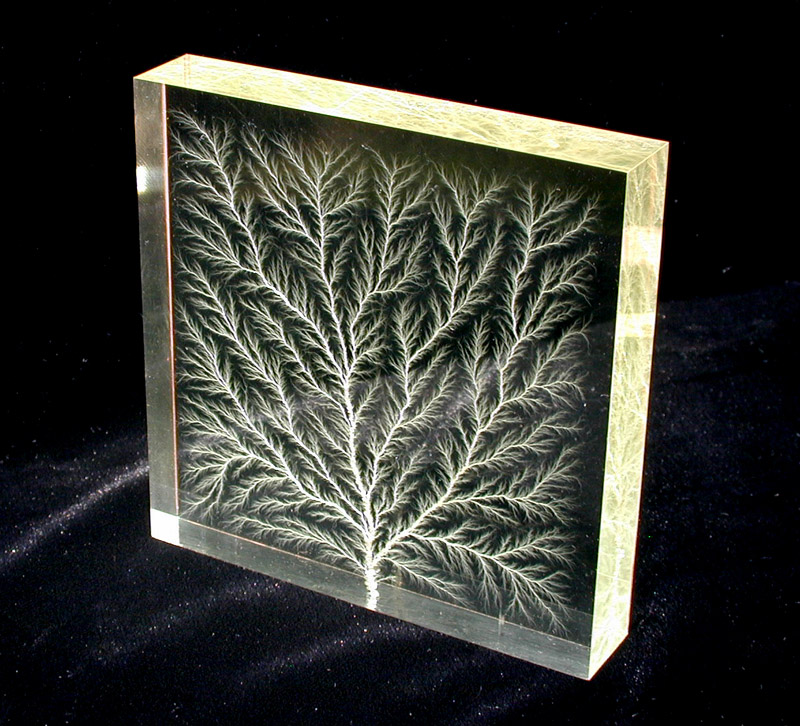

Lichtenberg Figure

## Particle Aggregation

- In many physical processes, from the creation of clouds, to snowflakes, to soot, smoke, and dust, particles aggregate in interesting ways.
- Particles exhibit [Brownian motion](https://en.wikipedia.org/wiki/Brownian_motion) as they move around, and when they come into contact with each other, they can stick together to form larger aggregates.
- Diffusion-limited aggregation (DLA) is an idealization of this process, and was first examined as a computational model by physicists Witten Jr and Sander (1981).
  - They showed that the structures that formed were often scale-invariant.

## DLA - The Rules

### SETUP

- Center `patch`:
  - I turn green and act as the seed of the aggregate.
- Spawn some number of turtles across the world.

### GO (at each clock tick)

- Each `turtle`:
  - Wiggles around randomly (i.e. Brownian motion).
  - If I touch a `green patch`, I turn the patch I’m on green and die.

## Extending the Model

**How can we extend this model to explore more of this mechanism?**

### Option 1 - Probabilistic sticking

### Option 2 - Neighbor influence

### Option 3 - Different aggregates

## Why study DLA?

- It can model a wide variety of physical processes (e.g. cloud formation, snowflakes, soot, smoke, dust).
- But it can also be used to model other phenomenon:
  - The growth of cities. (Fotheringham et al. 1989)
  - Barabasi would later contrast it to the preferential attachment model of network growth, which is more appropriate for modeling the growth of social networks. (Barabási and Albert 1999)
  - Ideas where *physical space* is the bottleneck for growth.

## References

Bak, Per. 1996. *How Nature Works: The Science of Self-Organised Criticality*. Springer.

Barabási, Albert-László, and Réka Albert. 1999. “Emergence of Scaling in Random Networks.” *Science* 286 (5439): 509–12.

Fotheringham, A. Stewart, Michael Batty, and Paul A. Longley. 1989. “DIFFUSION‐LIMITED AGGREGATION AND THE FRACTAL NATURE OF URBAN GROWTH.” *Papers in Regional Science* 67 (1): 55–69. https://doi.org/https://doi.org/10.1111/j.1435-5597.1989.tb01182.x.

Malamud, Bruce D, Gleb Morein, and Donald L Turcotte. 1998. “Forest Fires: An Example of Self-Organized Critical Behavior.” *Science* 281 (5384): 1840–42.

Mandelbrot, Benoit B. 1978. “The Fractal Geometry of Trees and Other Natural Phenomena.” *Geometrical Probability and Biological Structures: Buffon’s 200th Anniversary: Proceedings of the Buffon Bicentenary Symposium on Geometrical Probability, Image Analysis, Mathematical Stereology, and Their Relevance to the Determination of Biological Structures, Held in Paris, June 1977*, 235–49.

Schelling, Thomas C. 1971. “Dynamic Models of Segregation.” *Journal of Mathematical Sociology* 1 (2): 143–86.

Schelling, Thomas C. 1978. *Micromotives and Macrobehavior*. W. W. Norton & Company.

Witten Jr, Thomas A, and Leonard M Sander. 1981. “Diffusion-Limited Aggregation, a Kinetic Critical Phenomenon.” *Physical Review Letters* 47 (19): 1400.